# Practice with pivots, plots, etc.

In general, you should include both code and output in your rendered document. Each of your answers to the following problems should include a reasonable-looking output data frame, for instance using `gt`. Be mindful of the overall quality of your code and the appearance of your final document.

## Problem 1

Consider the `airport_data_speeds` set, available on Moodle, which is adapted from Triola’s *Elementary Statistics*[^1].

Tidy the data and then recreate the following plot as closely as possible.

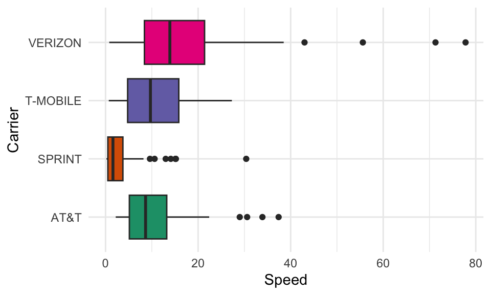

## Problem 2

Continue to use your tidied `airport_data_speeds` set. In how many of the airports in this set was Verizon the fastest? Answer this question using `group_by`.

## Problem 3

This problem uses the `drinks` data set, included in the `fivethirtyeight` package.

Tidy the data and then recreate the following plot as closely as possible.

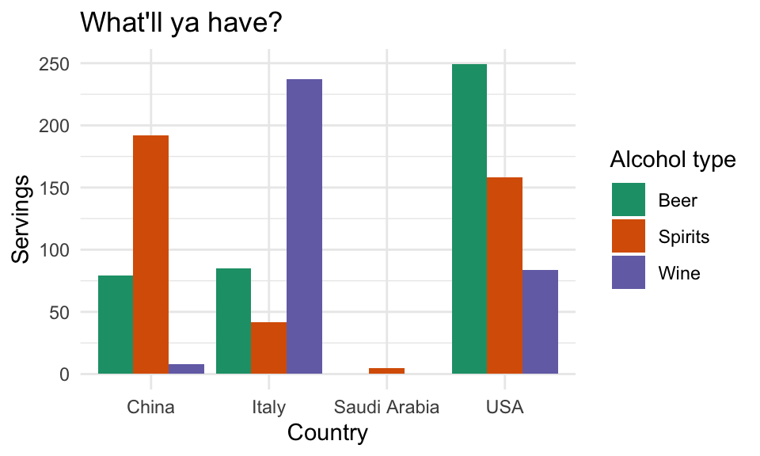

## Problem 4

This problem uses the `teeth` data set, available on Moodle. This 2004 set shows the annual sugar consumption in 90 countries as well as the mean number of decayed, missing, and filled teeth (DMFT) of residents at the age of 12[^2].

Write code to tidy this data so that each column represents a single variable and each row a single observation (country). Use that result to recreate the following plot as closely as possible.

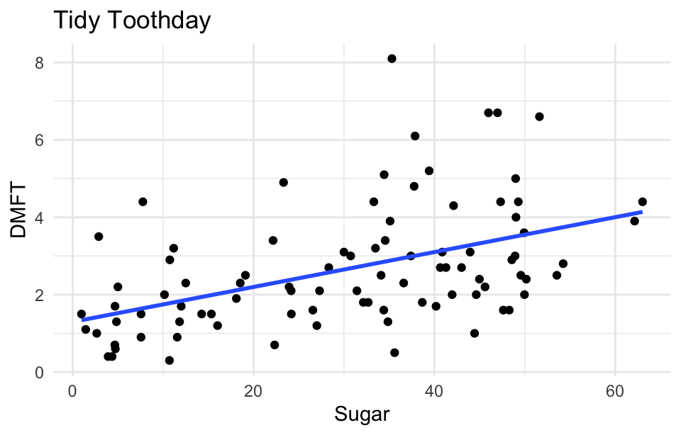

## Footnotes

[^1]: Triola, Mario F., et al. *Elementary Statistics*. Pearson/Addison-Wesley, 2006.
[^2]: Woodward, Mark. *Epidemiology: study design and data analysis*. CRC press, 2013.